# tarea_09, Thomas M. Rudolf

2023-10-13

# Ejercicio 1: crear funcion de verosim con el ejemplo de numéro de errores

```r
crear_log_verosim <- function(n=500, n_err){
  # n es tamaño de muestra
  # n_err el número de errores detectados (datos)
  n_corr <- n - n_err
  log_verosim <- function(p){
    n_err * log(p) + n_corr * log(1-p)
  }
}
```

### Pregunta: ¿qué devuelve esta función?

La funcíon regresa la probabilidad de un evento (en logaritmo naturalis - ln). Utiliza esta función para construir la función de log verosimilitud cuando los datos observados son n = 500, y le número de errores observados es 121

```r
n <- 500
n_err <- 121
p = 121/500
log_vero <- crear_log_verosim(500, 121)
```

### Pregunta: ¿de qué parámetros depende esta ultima función?

La función **log_verosim** es una funcion “simbolico” (así se llamaria en Matlab) de la función **crear_log_verosim**. El parametar que hay que definir es la probabilidad p y se varía enter 0 y 1 en deltas de 0.001. ¿Dónde quedaron los datos observados? En la funciòn **crear_log_verosim**. Usa max verosimilitud para estimar el porcentaje de errores en la tabla de datos de donde se sacó la muestra usa la función optimize

```r
sol <- optimize(log_vero, c(0, 1), maximum = TRUE)
sol$maximum
```

```
## [1] 0.2420091
```

### Grafica la funcion de verosimilitud para p entre cero y uno.

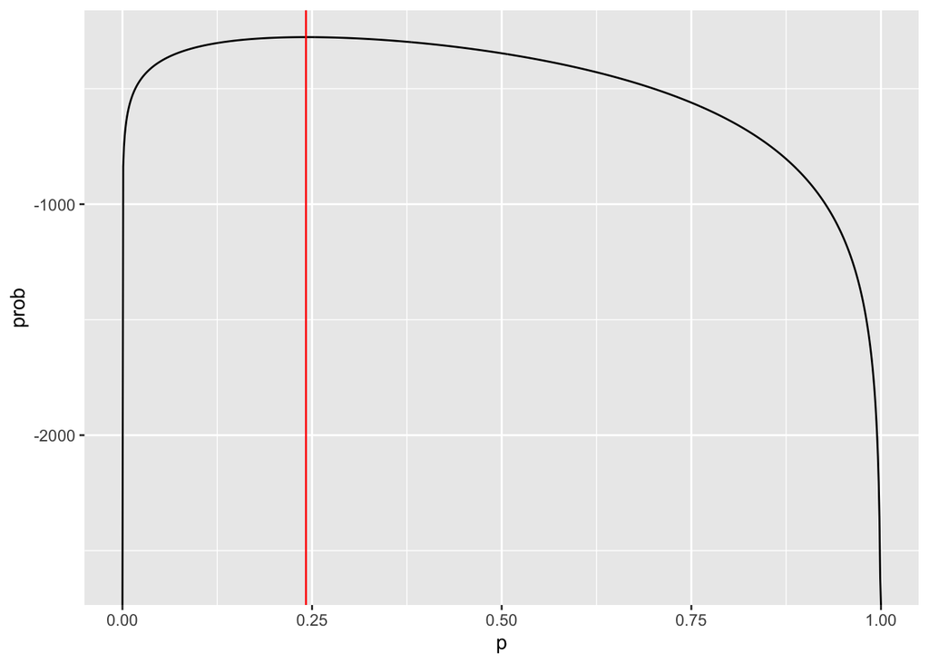

```r
grafica_tbl <- tibble(p = seq(0, 1, 0.001)) %>%
  mutate(prob = log_vero(p) )

g1<-ggplot(grafica_tbl, aes(x = p, y = prob)) +
  geom_line() +
  geom_vline(xintercept = sol$maximum, color="red")
g1
```

### Repite el ejercicio anterior si observas 317 errores

```r
log_vero <- crear_log_verosim(500, 317)
sol2 <- optimize(log_vero, c(0, 1), maximum = TRUE)
sol2$maximum
```

```
## [1] 0.6340049
```

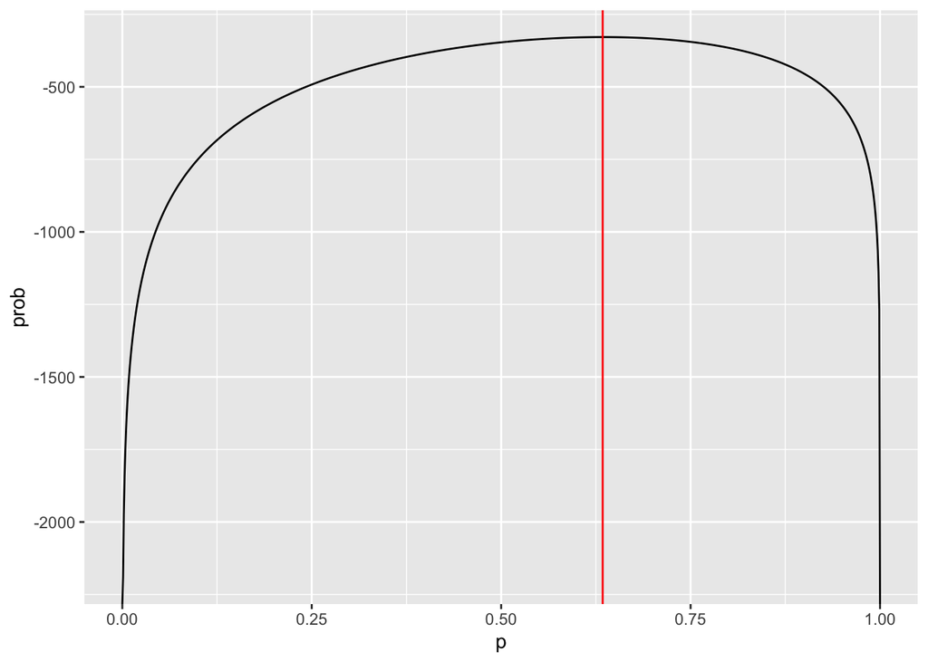

```r
grafica_tbl2 <- tibble(p = seq(0, 1, 0.001)) %>%
  mutate(prob = log_vero(p) )

g2<-ggplot(grafica_tbl2, aes(x = p, y = prob)) +
  geom_line() +
  geom_vline(xintercept = sol2$maximum, color="red")
g2
```

# Ejercicio 2: normal

## Estimación de parámetros de una distribución normal

### 1. Considera una muestra de variables aleatorias Gaussianas

Escribe la verosimilitud para una muestra de tamaño n y después escribe la función de log-verosimilitud.

Verosimilitud para un xi:

$$u_i = \frac{(x_i - \mu)}{2\sigma}$$
$$\mathcal{L}_n(x_i) = \frac{1}{\sigma \sqrt{2\pi}}\exp{u^2}$$
verosimilotud de $n$ $x_i$
$$\mathcal{L}_n(\theta) = \prod_{i=1} \mathcal{L}_n(x_i) = \prod_{i=1}
\frac{1}{\sigma \sqrt{2\pi}}\exp{u_1^2} =\prod_{i=1} \frac{1}{\sigma
\sqrt{2\pi}}\exp{\frac{(x_i - \mu)}{2\sigma}^2}$$
### 2. Generamos una mu y una sigma al azar para que

fijamos semilla

```r
set.seed(1234)
m <- runif(1, 5, 10) # media entre 5 y 10
desv_est <- runif(1, 0, 2) # desviación estándar entre 0 y 2
```

simulamos una muestra con la que trabajaremos.

```r
set.seed(123)
x <- rnorm(150, mean = m, sd = desv_est)
#log_verosim <- create_log_Gauss_Distribution(m , desv_est)
```

## 2. Checa tus datos usando un histograma

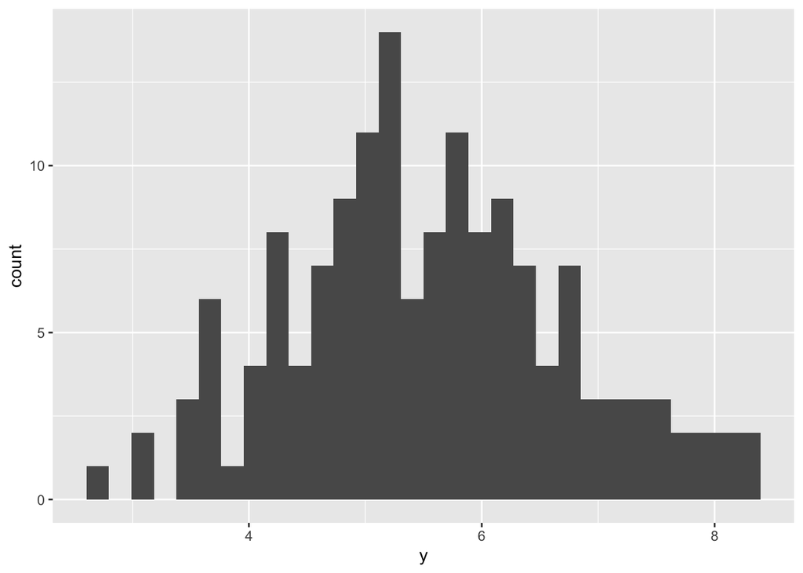

```r
gauss_tibble <- tibble(y = x)
ggplot(gauss_tibble, aes(x = y)) +
  geom_histogram()
```

### Primero estima a ojo por dónde creen que esté la media y la desviación estándar

La desviacion estandard debe estar como aprox 1.3 (8/6) y el promedio aprox. 5.

## 3.Estima la media y la desviación estándar usando estimador plug-in

```r
get_sample <- function(sample2eval){
  new_sample <- slice_sample(sample2eval, prop = 1, replace = TRUE)
  return(new_sample)
}
calc_estim <- function(data2estim, type = "mean"){
  estim_res <- data2estim %>%
    summarise(mean_gauss = mean(y), sd_gauss = sd(y))

  if(type == "mean"){
    return(estim_res$mean_gauss)
  }
  if(type == "sd"){
    return(estim_res$sd_gauss)
  }
}
media_est <- tibble(mean_estim = map_dbl(1:100, ~calc_estim(get_sample(gauss_tibble), "mean")))
media_est <- mean(media_est$mean_estim)
  de_est <- tibble(sd_estim = map_dbl(1:100, ~calc_estim(get_sample(gauss_tibble), "sd")))
  de_est <- mean(de_est$sd_estim)
gauss_tibble <- gauss_tibble %>% mutate(mean_estim = media_est, sd_estim = de_est)
gauss_tibble
```

```
## # A tibble: 150 × 3
##        y mean_estim sd_estim
##    <dbl>      <dbl>    <dbl>
##  1  4.87       5.53     1.18
##  2  5.28       5.53     1.18
##  3  7.51       5.53     1.18
##  4  5.66       5.53     1.18
##  5  5.73       5.53     1.18
##  6  7.70       5.53     1.18
##  7  6.14       5.53     1.18
##  8  3.99       5.53     1.18
##  9  4.71       5.53     1.18
## 10  5.01       5.53     1.18
## # ℹ 140 more rows
```

4. Escribe una función que regrese la función de verosimilitud dado una muestra (revisa las notas en la sección de más de un parámetro)

```r
create_log_Gauss_Distribution <- function(x){
  # f(x)= 1/(sig*sqrt(2*pi))*exp(-0.5*((xi-mu)/sig)^2)
  # log(1) = 0
  # log(x/y) = log(x) - log(y)
  # log(x*y) = log(x) + log(y)

  log_p <-function(pars){
    mu = pars[1]
    sig = pars[2]
    v <- sig*sqrt(2*pi)
    u <- (x-mu)/sig
    fx <- 1/(v)*exp(-0.5*(u)^2)
    # usando log
    log_fx <- (0 - log(v) - 0.5*mean(u^2))
    log_fx
  }
  log_p
}

crear_log_p <- function(x){
  log_p <- function(pars){
    media = pars[1]
    desv_est = pars[2]
    # ve la ecuación del ejercicio anterior
    z <- (x - media) / desv_est
    log_verosim <- -(log(desv_est) + 0.5 * mean(z ^ 2))
    log_verosim
  }
  log_p
}
log_p <- create_log_Gauss_Distribution(x) #crear_log_p(x)#
```

5.Usa la función del paso anterior para crear una función de verosimilitud que dependerá de mu y sigma.

6.Optimiza y compara tus estimaciones con las del paso 3.

```r
res <- optim(c(0, 0.5), log_p,
             control = list(fnscale = -1, maxit = 1000),
             method = "Nelder-Mead")
res$convergence
```

```
## [1] 0
```

```r
##
est_mv <- tibble(parameter = c("mu", "sigma"), estimador = res$par) %>%
  column_to_rownames(var = "parameter") %>% gt()
est_mv
```

| estimador |
| --- |
| 5.538433 |
| 1.177833 |